# Übungen zu Grundlagen der Inferenzstatistik, Teil 2

Lukas Stammler & Nathanael Lutz

2023-06-27

**Technischer Hinweis: Links in den Übungen öffnen Sie, indem sie darauf rechtsklicken und “Link in neuem Tab/Fenster öffnen” wählen.**

**Runden** Sie Kennzahlen und z-Werte auf zwei Stellen nach dem Komma, p-Werte auf drei Stellen nach dem Komma.

# Übungen zu Hypothesen

## Übung 1

### Aufgabe

Eine Studienberaterin der Berner Fachhochschule möchte wissen, wieviel Studierende im Monat für die Wohnungsmiete budgetieren müssen. Einer Empfehlung der ETH Zürich entnimmt sie, dass die durchschnittlichen Wohnkosten der Studierenden CHF 840.-/Monat betragen (https://ethz.ch/content/dam/ethz/main/education/finanzielles/files-de/lebenshaltung.pdf). Sie zweifelt, ob diese Angaben auch für Bern gelten. Formulieren Sie ihre Null- und Alternativhypothese.

### Lösung

$H_0:$ Die durchschnittlichen Mietkosten betragen CHF 840.-. $\mu = 840.-$  
$H_A:$ Die durchschnittlichen Mietkosten unterscheiden sich von CHF 840.-. $\mu \neq 840.-$

Die Alternativhypothese ist zweiseitig formuliert.

## Übung 2

### Aufgabe

Der Studienbeauftragte an der Universität Basel findet, dass der Betrag der ETH zu hoch angegeben ist. Welche Hypothesen formuliert er?

### Lösung

$H_0:$ Die durchschnittlichen Mietkosten betragen CHF 840.-. $\mu = 840.-$  
$H_A:$ Die durchschnittlichen Mietkosten sind tiefer als CHF 840.-. $\mu < 840.-$

Beachte, dass die Alternativhypothese einseitig formuliert ist.

## Übung 3

Der Studienbeauftragte an der Universität Basel (>10’000 Studierende) führt eine Befragung an einer Zufallsstichprobe von 400 Studierenden durch. Das Resultat seiner Untersuchung ergibt, dass die durchschnittlichen Mietkosten $\bar{x} = 730.-$ mit einer Standardabweichung von $s = 100.-$ betragen.

### Aufgabe

1. Sind die Voraussetzungen für ein Normalmodell erfüllt?
2. Unterscheidet sich das Ergebnis von der Aussage der ETH Zürich, dass die durchschnittlichen Mietkosten CHF 840.- betragen?

### Lösung

1. Sind die Voraussetzungen für ein Normalmodell erfüllt?

Es handelt sich um eine *Zufallsstichprobe*, der *Stichprobenumfang* ist kleiner als 10% der Population und wir dürfen *Unabhängigkeit der Daten* annehmen. Da die Daten der einzelnen Studierenden nicht vorliegen, können wir nicht auf Normalverteilung prüfen. Wir können aber davon ausgehen, dass das Normalmodell gültig ist, da die Stichprobe recht gross ist.

2. Unterscheidet sich das Ergebnis signifikant von der Aussage der ETH Zürich?

Der Standardfehler für das Basler Ergebnis ist $SE=s/\sqrt{n} = 100/\sqrt(400) = 5$. Das 95%-Vertrauensintervall ist $CI_{95} = 730 \pm 1.96 \times 5 = [720.2~,~739.8]$. Dieses Vertrauensintervall beinhaltet den Nullwert von 840 nicht und wir haben Evidenz dafür, dass die Nullhypothese zu Gunsten der Alternativhypothese verworfen werden kann.

## Übung 4

### Aufgabe

Wenn der Studienbeauftragte die Nullhypothese verwirft, welchen Fehler kann er dann möglicherweise begehen?

### Lösung

Einen Fehler 1. Art: Wenn wir die Nullhypothese $H_0$ verwerfen, besteht das Risiko, dass wir einen Fehler erster Art begehen. Bei einem Signifikanzniveau $\alpha = 0.05$ nehmen wir dieses Risiko in 5% unserer Entscheidungen in Kauf.

## Übung 5

Ein Fehler 1. Art am Gericht ist für den unschuldig Verurteilten eine gravierende Sache.

### Aufgabe

1. Wie kann am Gericht die Wahrscheinlichkeit für Fehler 1. Art vermindert werden?
2. Welche Auswirkungen hätte das für die Wahrscheinlichkeit, einen Fehler 2. Art zu begehen?

### Lösung

1. Das Gericht könnte eine strengere Beweisführung verlangen. Z.B. würden starke Indizien nicht mehr für eine Verurteilung reichen, sondern die Schuld des Angeklagten müsste effektiv bewiesen werden.
2. Die Wahrscheinlichkeit für Fehler 2. Art würde ansteigen, da auf Grund der strengeren Beweisführung und mangels harten Beweisen ein tatsächlich Schuldiger eher freigesprochen wird.

## Übung 6

### Aufgabe

Wenn wir alle Variablen der folgenden Datensätze auswerten und für jede Variable einen Hypothesentest durchführen, wie oft werden wir im Durchschnitt einen Fehler 1. Art begehen? (Signifikanzniveau $\alpha = 0.05$)

1. Datensatz mit 20 Variablen
2. Datensatz mit 60 Variablen
3. Datensatz mit 120 Variablen

### Lösung

Ein Signifikanzniveau $\alpha = 0.05$ bedeutet, dass wir in 5% der Entscheidungen einen Fehler 1. Art in Kauf nehmen.

1. Datensatz mit 20 Variablen: 0.05 x 20 = 1
2. Datensatz mit 60 Variablen: 0.05 x 60 = 3
3. Datensatz mit 120 Variablen: 0.05 x 120 = 6

# Übungen zum p-Wert

## Übung 7

### Aufgabe

In Übung 2 und 3 hat der Studienbeauftragte eine einseitig Alternativhypothese formuliert: $H_A: \mu < 840$. Seine Ergebnisse waren, dass die durchschnittlichen Mietkosten $\bar{x} = 730.-, s = 100.-$ betragen. Ist dies ein signifikanter Unterschied zu 840.-? Signifikanzniveau $\alpha = 0.05$

### Lösung

**Variante 1:** Prüfung mittels 95%-Konfidenzintervall

Das 95%-Konfidenzintervall für die Mietkosten ergibt in Übung 3 mit [720.2, 739.8]. Der Nullwert von CHF 840.- ist in diesem Konfidenzintervall nicht enthalten und wir haben Evidenz dafür, dass sich die durchschnittlichen Mietkosten signifikant von 840.- unterscheiden.

**Variante 2:** Prüfung mittels Teststatisik

$$z =
\frac{\bar{x}-\mu_0}{SE}$$

Aus Übung 3 wissen wir, dass $\bar{x} = 730$ und $SE = 5$.

$$z = \frac{730-840}{5} = \frac{-110}{5} =
-22$$

Ein z-Wert von -22 ist extrem klein und kann nicht in der z-Tabelle abgelesen werden. Die Berechnung der Wahrscheinlichkeit $p$ für $z=-22$ ergibt

```r
pnorm(-22)
```

```
## [1] 1.439892e-107
```

*Die durchschnittlichen Mietzinsen, die Studierende bezahlen betragen CHF 730.- [720.2, 739.8]. Dieser Wert ist statistisch signifikant geringer als CHF 840.-, p < 0.001.*

## Übung 8

Sie müssen eine neuen Physiotherapie-Methode bei Rückenschmerzen anhand einer Stichprobe von $n = 25$ Patienten beurteilen: Nach einwöchiger Physiotherapie mit der neuen Methode nahmen die Rückenschmerzen bei den 25 Proband:innen auf der VAS (visuelle Analogskala, Wert von 0 = kein Schmerz bis 100 = maximaler Schmerz) um durchschnittlich $\bar{x} = -17.8$ Punkte ab. Die Standardabweichung beträgt $s = 10$ Punkte.

Ein Langzeiterfahrungswert mit der bisherigen Referenztherapie beträgt -15 Punkte auf der VAS-Skala.

### Aufgabe

Ist die neue Therapiemethode besser oder schlechter als die bisherige Referenztherapie? Formulieren sie die Hypothesen und prüfen Sie diese mittels Konfidenzintervall oder Teststatistik. Signifikanzniveau $\alpha = 0.05$

### Lösung

**Hypothesen**

$H_0: \bar{x} = -15$  
$H_A: \bar{x} \neq -15$

**Variante 1:** Prüfung mittels Konfidenzintervall

Dem Signifikanzniveau $\alpha = 0.05$ entspricht ein 95%-Konfidenzintervall.

1. Schritt: Berechnung des Standardfehlers

$$SE = \frac{s}{\sqrt{n}} =
\frac{10}{\sqrt{25}} = \frac{10}{5} = 2$$

2. Schritt: Berechnung des 95% Konfidenzintervalls (mit z = 1.96)

$$CI_{95} = \bar{x} \pm 1.96 \times SE =
-17.8 \pm 1.96 \times 2 = -17.8 \pm 3.92 = [-21.72, -13.88]$$

3. Schritt: Interpretation

Die neue Methode reduziert die Schmerzen auf der VAS-Skala um durchschnittlich -17.8 [-21.72, -13.88] Punkte. Das 95%-Konfidenzintervall enthält den Referenzwert von -15 Punkten auf der VAS-Skala. Daher haben wir keine Evidenz für einen statistisch signifikanten Effekt der neuen Methode.

**Variante 2:** Prüfung mittels Teststatistik

$$z = \frac{\bar{x}-\mu_0}{SE} =
\frac{-17.8 + 15}{2} = -1.4$$

Wie wahrscheinlich wäre unter $H_0$ das beobachtete Ergebnis?

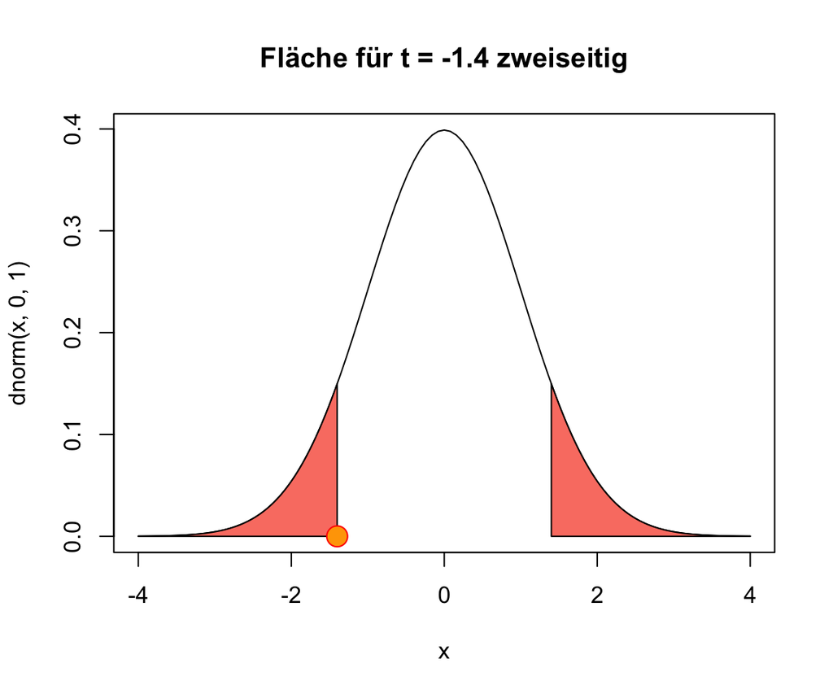

```r
p <- 2 * (1- pnorm(abs(-1.4)))
p
```

```
## [1] 0.1615133
```

Die Wahrscheinlichkeit für eine Teststatistik so extrem oder noch extremer als die beobachtete beträgt $p = 0.162$.

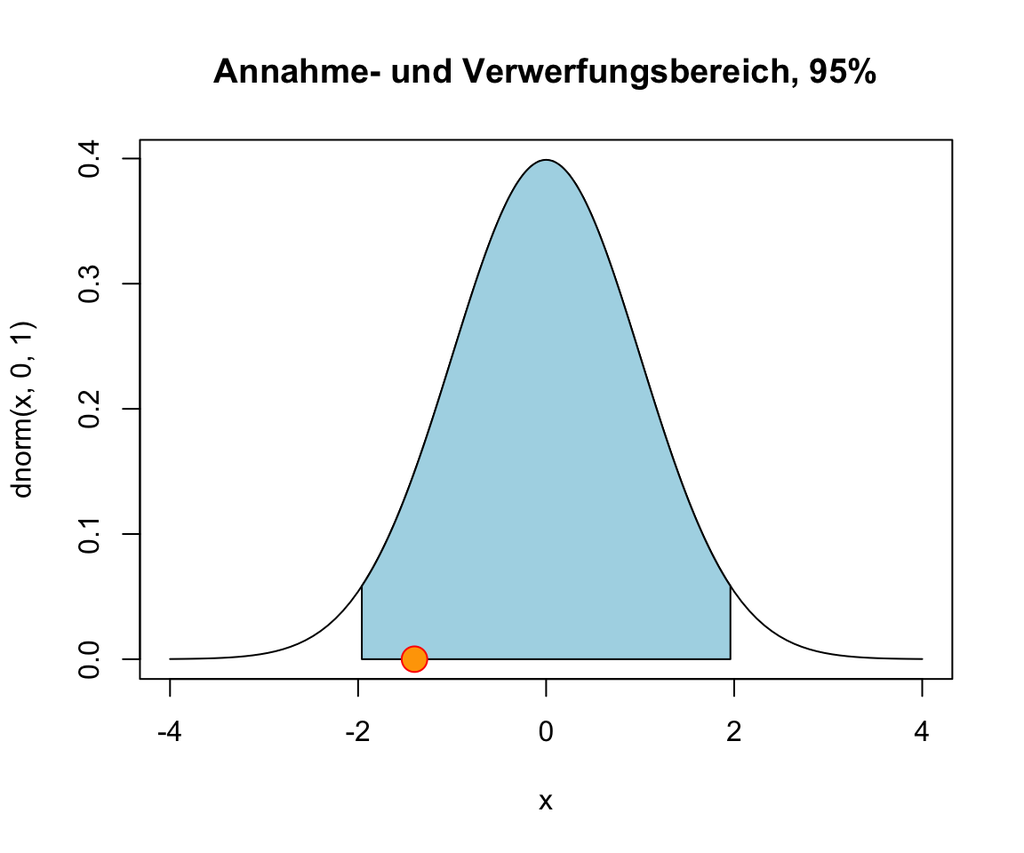

Die Grenzen zwischen Annahmebereich (blaue Fläche) und Verwerfungsbereich (weisse Enden der Kurve) bei einem Signifikanzniveau $\alpha = 0.05$, liegt für die Standardnormalverteilung bei -1.96 und +1.96. Unsere Teststatistik $z = -1.4$ liegt innerhalb des Annahmebereichs und wir haben keine Evidenz gegen die Nullhypothese.

## Übung 9

### Aufgabe

Weil Sie sicher sind, dass die neue Methode besser ist, haben Sie die Studie mit einer neuen Stichprobe im Umfang von $n = 100$ erneut durchgeführt. Ihre Kennzahlen sind die gleichen wie in Übung 8, also $\bar{x} = -17.8$, $s = 10$. Der Referenzwert ist immer noch -15 und das Signifikanzniveau ist $\alpha = 0.05$.

Welche Folgen hat die Erhöhung des Stichprobenumfangs für Ihre Schlussfolgerungen?

### Lösung

**Hypothesen**

$H_0: \bar{x} = -15$  
$H_A: \bar{x} \neq -15$

**Variante 1:** Prüfung mittels 95% Konfidenzintervall

1. Schritt: Berechnung des Standardfehlers

$$SE = \frac{s}{\sqrt{n}} =
\frac{10}{\sqrt{100}} = \frac{10}{10} = 1$$
Mit der vierfachen Stichprobengrösse halbiert sich der Standardfehler $SE = 1$!

2. Schritt: Berechnung des 95% Konfidenzintervalls (mit z = 1.96)

$$CI_{95} = \bar{x} \pm 1.96 \times SE =
-17.8 \pm 1.96 \times 1 = -17.8 \pm 1.96 = [-19.76, -15.84]$$

3. Schritt: Interpretation

Die zweite Studie zur neuen Methode mit $n = 100$ reduziert die Schmerzen auf der VAS-Skala um durchschnittlich -17.8 [-19.76, -15.84] Punkte. Das 95%-Konfidenzintervall enthält den Referenzwert von -15 Punkten auf der VAS-Skala nicht. Damit haben wir Evidenz für einen statistisch signifikanten Effekt und verwerfen die Nullhypothese.

**Variante 2:** Prüfung mittels Teststatistik

$$z = \frac{\bar{x}-\mu_0}{SE} =
\frac{-17.8 + 15}{1} = -2.8$$

Wie wahrscheinlich wäre unter $H_0$ das beobachtete Ergebnis?

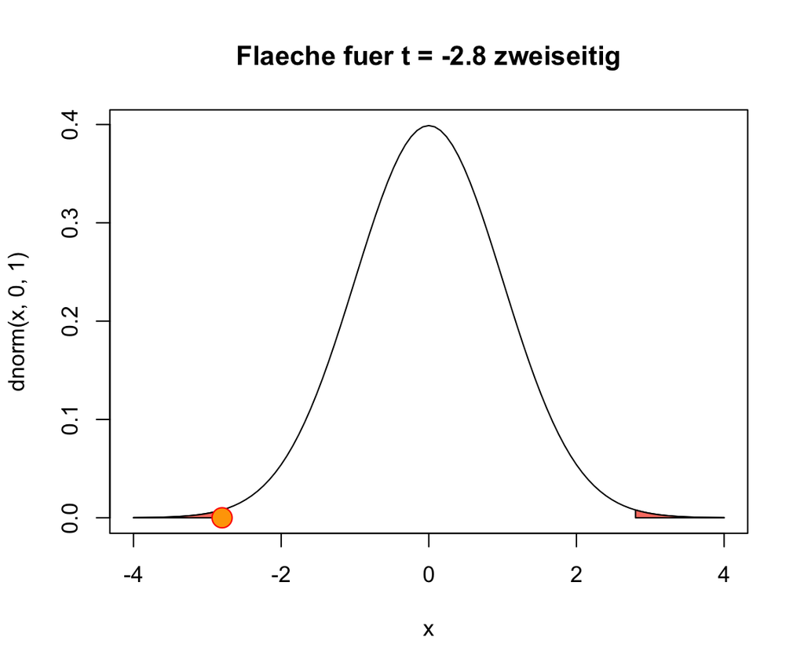

```r
p <- 2 * (1- pnorm(abs(-2.8)))
p
```

```
## [1] 0.005110261
```

Die Wahrscheinlichkeit für eine Teststatistik so extrem oder noch extremer als die beobachtete beträgt $p = 0.005$.

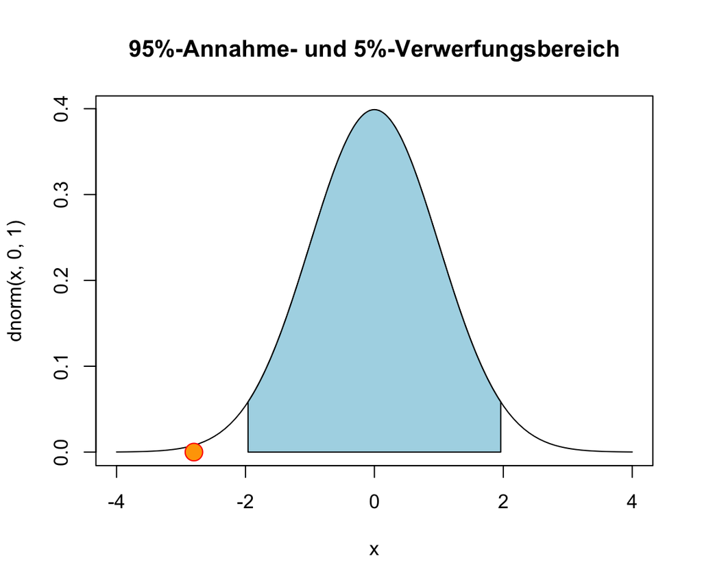

Die Grenzen zwischen Annahmebereich (blaue Fläche) und Verwerfungsbereich (weisse Enden der Kurve) bei einem Signifikanzniveau $\alpha = 0.05$, liegt für die Standardnormalverteilung bei -1.96 und +1.96. Unsere Teststatistik $z = -2.8$ liegt innerhalb des Verwerfungsbereichs und wir haben Evidenz gegen die Nullhypothese.